# תרגיל בית 1ג’ (תרגול ב-R)

היכרות ראשונית עם R

בתרגיל זה תתקינו את R, את חבילת `tidyverse` ותתרגלו מעט עבודה עם נתונים.

## חלק ראשון

התקינו את תוכנת R ואת RStudio.

את תוכנת R ניתן להוריד בקישור הבא:

https://cran.r-project.org/bin/windows/base/

את RStudio ניתן להוריד בקישור הבא:

https://www.rstudio.com/products/rstudio/download/#download

שימו לב להשתמש בגרסאות המתאימות לכם (יש גרסאות שונות ל-Windows, macOS, ו-Linux)

כעת לאחר שהתקנתם, הפעילו את RStudio והתקינו את חבילת `tidyverse` על ידי הקלדה ב-Console של:

```r
install.packages("tidyverse")
```

זה עשוי לקחת קצת זמן, אז התאזרו בסבלנות.

אם קיבלתם הודעת שגיאה כגון: *Error in install.packages : cannot open file* זה כנראה נובע מבעיות הרשאה לתיקייה אליה R מנסה להתקין את החבילה. אפשר לפתור את הבעיה הזו על ידי העלאת RStudio עם כפתור ימני של העכבר, ואז Run as Administrator (ואז לנסות להתקין מחדש).

## חלק שני

התקינו את חבילת `palmerpenguins`. השתמשו באותה הפקודה בה השתמשנו בחלק הראשון לצורך התקנת חבילה (רק שנו את השם tidyverse לשם של החבילה `palmerpenguins`).

כעת השתמשו בקוד הבא ותארו מהם הנתונים הקיימים בטבלה `penguins`:

```r
library(tidyverse)
library(palmerpenguins)

glimpse(penguins)
```

הריצו גם את הפקודות הבאות וכתבו מה ההבדל בין הפונקציה `glimpse`, `head`, `tail`, `view`, ולרשום `penguins` ב-console.

```r
head(penguins)
tail(penguins)
view(penguins)
penguins
```

- מה מתארת כל שורה בטבלה?
- מה מתאר המשתנה island?
- מה מתאר המשתנה species?

השתמשו בפונקציה count בדומה לאופן המתואר להלן, וענו על השאלות:

- כמה איים מתועדים בטבלה?
- כמה זכרים מתועדים בטבלה?
- לכמה תצפיות חסרים נתונים זכר/נקבה?

דוגמה לשימוש בפונקציה count (תצטרכו להרחיב את הדוגמה הזו על ידי שינוי הקוד)

```r
penguins %>%
  count(species)
```

## חלק שלישי

הקוד הבא מצייר תרשים של הקשר בין אורך מקור ואורך כנף.

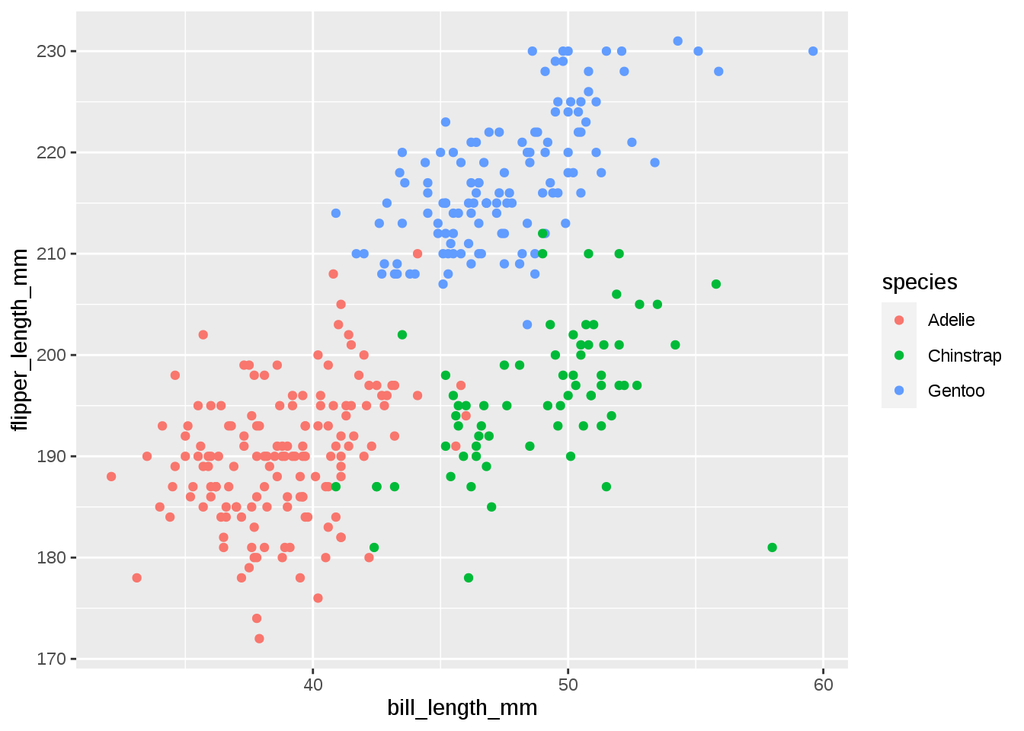

```r
ggplot(data = penguins,
       aes(x = bill_length_mm,
           y = flipper_length_mm,
           color = species)) +
  geom_point()
```

ענו על השאלות הבאות: